# Gantt Chart

Jen Baron

May 5, 2020

Source Code: https://www.molecularecologist.com/2019/01/simple-gantt-charts-in-r-with-ggplot2-and-the-tidyverse/

I open a terminal and load up the tidyverse packages:

```r
library(tidyverse)
library(nationalparkcolors)
```

# MSc

Then I load the text file containing the schedule data. I also set up two vectors containing the unique names of activities in the schedule file, and the unique names of the project elements. These will come in handy for controlling the display order of the items in the Gantt chart.

```r
gantt <- read.csv("data/gantt.csv", h=T)
gantt
```

```
##    Item                              Activity     Project.element      Start
## 1     1                     Literature review Project Development 2019.09.01
## 2     2                  Proposal development         Deliverable 2019.12.01
## 3     3              Initial data exploration Project Development 2020.02.01
## 4     4  Classification & transition matrices          Statistics 2020.04.14
## 5     5    Quantification of landscape change            Analysis 2020.07.01
## 6     6                                   PCA          Statistics 2020.09.01
## 7     7   Quantification of landscape drivers            Analysis 2020.09.14
## 8     8                                   RDA          Statistics 2020.11.01
## 9     9 Variance partitioning & linear models          Statistics 2020.11.14
## 10   10                   Spatial assessment             Analysis 2020.11.01
## 11   11             Interpretation of results            Analysis 2020.12.01
## 12   12                     Thesis: Chapter 1         Deliverable 2021.01.01
## 13   13                     Thesis: Chapter 2         Deliverable 2021.02.14
## 14   14                     Thesis: Chapter 3         Deliverable 2021.04.01
```

[output cut: 21 more lines]

```r
acts <- c(
  "Literature review",
  "Proposal development",
  "Initial data exploration",
  "Classification & transition matrices",
  "Quantification of landscape change",
  "PCA",
  "Quantification of landscape drivers",
  "RDA",
  "Variance partitioning & linear models",
  "Spatial assessment ",
  "Interpretation of results",
  "Thesis: Chapter 1",
  "Thesis: Chapter 2",
  "Thesis: Chapter 3",
  "Thesis: Working draft",
  "Publication development",
  "Thesis: Submission & defense")

els <- c("Project Development",
         "Deliverable",
         "Analysis",
         "Statistics")
```

To work neatly with ggplot, I need the start and end dates to be in a single column, with another column to identify whether they’re the start or end date. This is the job of the gather() function. I’m also going to convert the Activities and Project.element columns into factors, with levels defined to control the order in which they appear in the chart. This is where those two vectors of activity and project element names come in — the ordering of names in those vectors can determine the ordering of levels in the factors.

With tidyverse notation, I can do this all on one line of code:

```r
g.gantt <- gather(gantt, "state", "date", 4:5) %>% mutate(date = as.Date(date, "%Y.%m.%d"), Activity=factor(Activity, acts[length(acts):1]), Project.element=factor(Project.element, els))

tail(g.gantt)
```

```
##    Item                     Activity Project.element state       date
## 29   12            Thesis: Chapter 1     Deliverable   End 2021-02-14
## 30   13            Thesis: Chapter 2     Deliverable   End 2021-04-01
## 31   14            Thesis: Chapter 3     Deliverable   End 2021-05-14
## 32   15        Thesis: Working draft     Deliverable   End 2021-07-01
## 33   16      Publication development     Deliverable   End 2021-08-31
## 34   17 Thesis: Submission & defense     Deliverable   End 2021-08-31
```

```r
pal <- park_palette("GrandTeton")
```

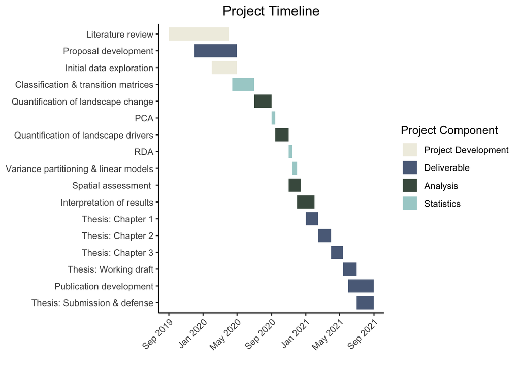

```r
gantt.chart <- ggplot(g.gantt,
       aes(date, Activity, colour = Project.element, group = Item)) +
       geom_line(size = 6) +
       scale_color_manual(values = pal, name = "Project Component") +
       labs(x = "", y = NULL, title = "Project Timeline") +
       theme_classic() +
       theme(axis.text.x = element_text(angle = 45, hjust = 1), plot.title = element_text(hjust = 0.5)) +
       scale_x_date(date_labels =  "%b %Y", breaks = as.Date(c("2019-09-01", "2020-01-1", "2020-05-01", "2020-09-01", "2021-01-01", "2021-05-01","2021-09-01")))

gantt.chart
```

```r
ggsave("figures/gantt.chart.jpeg", gantt.chart, units = "cm", width = 20, height = 12)
```

# PhD

```r
gantt2 <- read.csv("data/ganttPhD.csv", h=T)
gantt2
```

```
##    Item                     Activity     Project.element      Start         End
## 1     1            Literature Review Project Development 2019.09.01  2020.04.01
## 2     2   GEM 500: Landscape Ecology              Course 2019.09.01  2019.12.01
## 3     3     FRST 547: Forestry in BC              Course 2019.09.01  2019.12.01
## 4     4   FRST 505: Dendrochronology              Course 2020.01.01  2020.05.01
## 5     5                 MSc Proposal         Deliverable 2020.02.01  2020.04.01
## 6     6    Data Acquisition (Ch 2-3) Project Development 2020.04.01  2020.08.01
## 7     7          Committee Meeting 1           Milestone 2020.05.01  2020.05.14
## 8     8     Air Photo Classification            Analysis 2020.07.01  2020.12.01
## 9     9      FRST 505: Fire Ecology               Course 2020.09.01  2020.12.01
## 10   10            Thesis: Chapter 1         Deliverable 2020.09.01  2020.12.01
## 11   11           Air Photo Analysis            Analysis 2020.10.01  2021.03.01
## 12   12          Committee Meeting 2           Milestone 2020.11.01  2020.11.14
## 13   13            Thesis: Chapter 2         Deliverable 2020.12.01 2021.04.30
## 14   14              Transfer to PhD           Milestone 2021.01.01  2021.01.14
## 15   15                 PhD Proposal         Deliverable 2021.02.01  2021.04.01
## 16   16          Committee Meeting 3           Milestone 2021.04.01  2021.04.14
## 17   17           Comprehensive Exam           Milestone 2021.04.01  2021.06.14
## 18   18            Thesis: Chapter 3         Deliverable 2021.07.01  2021.11.01
## 19   19     Scholarship Applications Project Development 2021.08.01  2021.10.01
## 20   20    Data Acquisition (Ch 4-5) Project Development 2021.10.01  2022.03.01
## 21   21            Model Development            Analysis 2022.01.01  2022.08.01
## 22   22          Committee Meeting 4           Milestone 2022.04.01  2022.04.14
## 23   23            Thesis: Chapter 4         Deliverable 2022.04.01  2022.08.01
## 24   24             Model Refinement            Analysis 2022.08.01  2023.03.01
## 25   25          Committee Meeting 5           Milestone 2023.02.01  2023.02.14
## 26   26            Thesis: Chapter 5         Deliverable 2022.12.01  2023.04.01
## 27   27          Committee Meeting 6           Milestone 2023.04.01  2023.04.14
## 28   28                Thesis: Draft         Deliverable 2023.02.01  2023.06.01
## 29   29 Thesis: Submission & Defense         Deliverable 2023.07.01  2023.08.14
```

```r
acts2 <- c(
"Literature Review",
"GEM 500: Landscape Ecology",
"FRST 547: Forestry in BC",
"FRST 505: Dendrochronology",
"MSc Proposal",
"Data Acquisition (Ch 2-3)",
"Committee Meeting 1",
"Air Photo Classification",
"FRST 505: Fire Ecology ",
"Thesis: Chapter 1",
"Air Photo Analysis",
"Committee Meeting 2",
"Thesis: Chapter 2",
"Transfer to PhD",
"PhD Proposal",
"Committee Meeting 3",
"Comprehensive Exam",
"Thesis: Chapter 3",
"Scholarship Applications",
"Data Acquisition (Ch 4-5)",
"Model Development",
"Committee Meeting 4",
"Thesis: Chapter 4",
"Model Refinement",
"Committee Meeting 5",
"Thesis: Chapter 5",
"Committee Meeting 6",
"Thesis: Draft",
"Thesis: Submission & Defense")

els2 <- c("Project Development",
         "Course",
         "Milestone",
         "Deliverable",
         "Analysis")
```

```r
g.gantt2 <- gather(gantt2, "state", "date", 4:5) %>% mutate(date = as.Date(date, "%Y.%m.%d"), Activity=factor(Activity, acts2[length(acts2):1]), Project.element=factor(Project.element, els2))

tail(g.gantt2)
```

```
##    Item                     Activity Project.element state       date
## 53   24             Model Refinement        Analysis   End 2023-03-01
## 54   25          Committee Meeting 5       Milestone   End 2023-02-14
## 55   26            Thesis: Chapter 5     Deliverable   End 2023-04-01
## 56   27          Committee Meeting 6       Milestone   End 2023-04-14
## 57   28                Thesis: Draft     Deliverable   End 2023-06-01
## 58   29 Thesis: Submission & Defense     Deliverable   End 2023-08-14
```

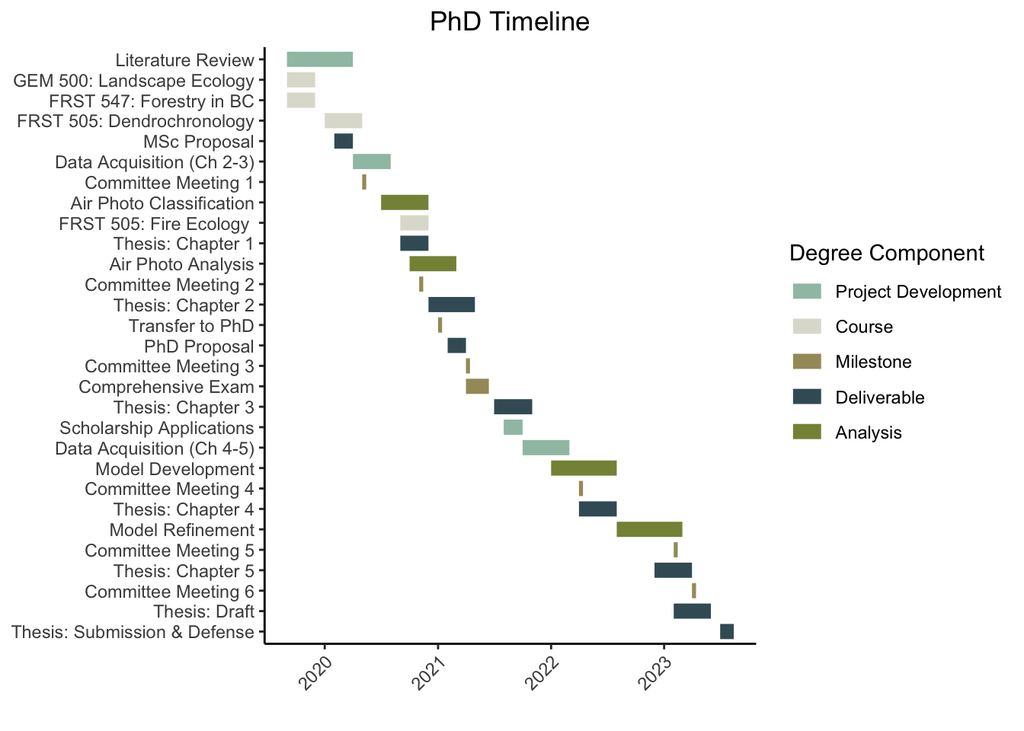

```r
pal <- park_palette("Yosemite")

gantt.chart2 <- ggplot(g.gantt2,
       aes(date, Activity, colour = Project.element, group = Item)) +
       geom_line(size = 3.5) +
       scale_color_manual(values = pal, name = "Degree Component") +
       labs(x = "", y = NULL, title = "PhD Timeline") +
       theme_classic() +
  scale_x_date(date_breaks = "1 year", date_labels = "%Y") +
       theme(axis.text.x = element_text(angle = 45, hjust = 1), plot.title = element_text(hjust = 0.5))

gantt.chart2
```

```r
#ggsave("figures/gantt.chart2.jpeg", gantt.chart2, units = "cm", width = 20, height = 12)
```

# PhD_simple

```r
gantt3 <- read.csv("data/ganttPhD_simple.csv", h=T)
gantt3
```

```
##    Item                     Activity     Project.element      Start         End
## 1     1            Literature Review Project Development 2019.09.01  2020.04.01
## 2     2                 MSc Proposal           Milestone 2020.02.01  2020.04.01
## 3     3           Data Acquisition I Project Development 2020.04.01  2020.08.01
## 4     4     Air Photo Classification            Analysis 2020.09.01  2021.04.01
## 5     5     Thesis: Review Chapter 1         Deliverable 2020.10.01 2021.03.30
## 6     6     Thesis: Review Chapter 2         Deliverable 2021.01.01 2021.04.30
## 7     7                 PhD Proposal           Milestone 2021.02.01  2021.05.01
## 8     8           Air Photo Analysis            Analysis 2021.04.01  2021.10.01
## 9     9           Comprehensive Exam           Milestone 2021.05.01  2021.07.14
## 10   10       Thesis: Data Chapter 1         Deliverable 2021.07.01  2021.11.01
## 11   11  PGS-D & Vanier Applications Project Development 2021.08.01  2021.10.01
## 12   12          Data Acquisition II Project Development 2021.10.01  2022.03.01
## 13   13            Model Development            Analysis 2022.01.01  2022.08.01
## 14   14       Thesis: Data Chapter 2         Deliverable 2022.04.01  2022.08.01
## 15   15             Model Refinement            Analysis 2022.08.01  2023.03.01
## 16   16       Thesis: Data Chapter 3         Deliverable 2022.12.01  2023.04.01
## 17   17 Thesis: Submission & Defense           Milestone 2023.07.01  2023.08.14
```

```r
acts3 <- c(
"Literature Review",
"MSc Proposal",
"Data Acquisition I",
"Air Photo Classification",
"Thesis: Review Chapter 1",
"Thesis: Review Chapter 2",
"PhD Proposal",
"Air Photo Analysis",
"Comprehensive Exam",
"Thesis: Data Chapter 1",
"PGS-D & Vanier Applications",
"Data Acquisition II",
"Model Development",
"Thesis: Data Chapter 2",
"Model Refinement",
"Thesis: Data Chapter 3",
"Thesis: Submission & Defense")

els3 <- c("Project Development",
          "Analysis",
          "Milestone",
         "Deliverable")


g.gantt3 <- gather(gantt3, "state", "date", 4:5) %>% mutate(date = as.Date(date, "%Y.%m.%d"), Activity=factor(Activity, acts3[length(acts3):1]), Project.element=factor(Project.element, els3))

tail(g.gantt3)
```

```
##    Item                     Activity     Project.element state       date
## 29   12          Data Acquisition II Project Development   End 2022-03-01
## 30   13            Model Development            Analysis   End 2022-08-01
## 31   14       Thesis: Data Chapter 2         Deliverable   End 2022-08-01
## 32   15             Model Refinement            Analysis   End 2023-03-01
## 33   16       Thesis: Data Chapter 3         Deliverable   End 2023-04-01
## 34   17 Thesis: Submission & Defense           Milestone   End 2023-08-14
```

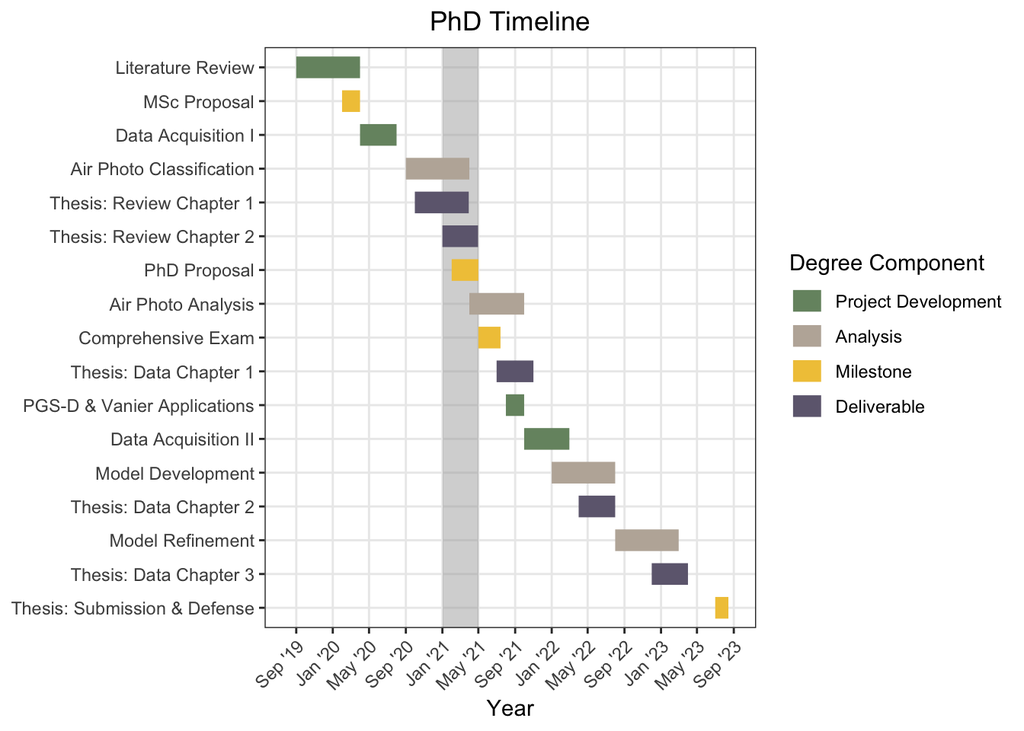

```r
pal <- park_palette("Redwoods")

gantt.chart3 <- ggplot(g.gantt3, aes(date, Activity, colour = Project.element, group = Item)) +
   geom_rect(xmin = as.Date("2021-1-1"), xmax = as.Date("2021-5-1"),
              ymin = -Inf,
              ymax = +Inf, fill = "lightgray", alpha = 0.03, colour = NA) +
  geom_line(size=5) +
  # geom_segment(aes(x = as.Date("2021-1-1"), y = "Air Photo Classification",
  #                     xend = as.Date("2021-5-1"), yend = "Air Photo Classification"),
  #              arrow = arrow(length = unit(0.3, "cm"))) +
  scale_color_manual(values = pal, name = "Degree Component") +
  labs(x = "", y = NULL, title = "PhD Timeline") +
  scale_x_date(date_breaks = "4 months", name = "Year", date_minor_breaks = "4 months",
               limits = as.Date(c("2019-8-1", "2023-9-1")),
               date_labels = "%b '%y") +
  theme_bw() +
       theme(axis.text.x = element_text(angle = 45, hjust = 1), plot.title = element_text(hjust = 0.5))


gantt.chart3
```

```r
#ggsave("figures/gantt.chart3.jpeg", gantt.chart3, units = "cm", width = 20, height = 12)
```